# Chapter 8 - Exercise 9

#### (g)

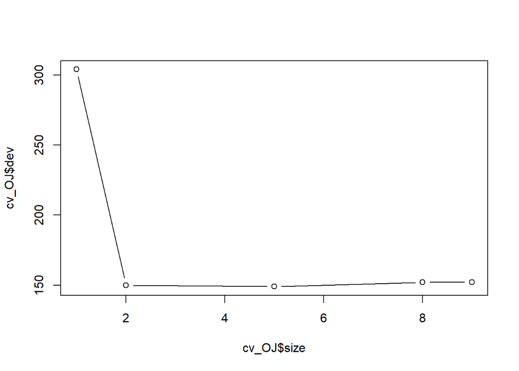

```r
plot(cv_OJ$size, cv_OJ$dev, type="b")
```

#### (h)

According to these results, the tree with 5 terminal nodes has the lowest classification error rate, with 149 classification errors.

#### (i)

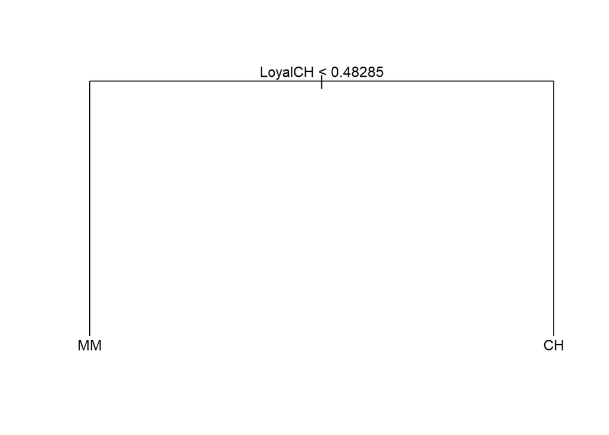

```r
pruned_OJ = prune.misclass(tree_Purchase, best=2)
plot(pruned_OJ)
text(pruned_OJ, pretty = 0)
```

#### (j)

```r
summary(pruned_OJ)
```

```
##
## Classification tree:
## snip.tree(tree = tree_Purchase, nodes = 2:3)
## Variables actually used in tree construction:
## [1] "LoyalCH"
## Number of terminal nodes:  2
## Residual mean deviance:  0.9556 = 762.5 / 798
## Misclassification error rate: 0.1862 = 149 / 800
```

The training error rate of unpruned tree is 14.75%, the training error rate of pruned tree is 18.62%, which is higher than unpruned tree.

#### (k)

```r
pruned_test_pred = predict(pruned_OJ, OJ_test, type="class")
table(OJ_test$Purchase, pruned_test_pred)
```

```
##     pruned_test_pred
##       CH  MM
##   CH 131  26
##   MM  29  84
```

The test error rate is (29 + 26)/(131 + 26 + 29 + 84) = 20.37%.

The teat error rate of unpruned tree is 19.26%, the test error rate of pruned tree is 20.37%, which is higher than unpruned tree. It seems that the unpruned tree, which has more complexity structure, performance little better.